# Risk Factor Analysis

## Outcome Variable

**Outcome Variable:** stunted

## Predictor Variables

**Intervention Variable:** fage

**Adjustment Set:**

unadjusted

## Stratifying Variables

The analysis was stratified on these variable(s):

- agecat
- studyid
- country

## Data Summary

| agecat | studyid | country | fage | stunted | n_cell | n |
| --- | --- | --- | --- | --- | --- | --- |
| Birth | ki0047075b-MAL-ED | BANGLADESH | >=38 | 0 | 52 | 133 |
| Birth | ki0047075b-MAL-ED | BANGLADESH | >=38 | 1 | 11 | 133 |
| Birth | ki0047075b-MAL-ED | BANGLADESH | <32 | 0 | 21 | 133 |
| Birth | ki0047075b-MAL-ED | BANGLADESH | <32 | 1 | 4 | 133 |
| Birth | ki0047075b-MAL-ED | BANGLADESH | [32-38) | 0 | 40 | 133 |
| Birth | ki0047075b-MAL-ED | BANGLADESH | [32-38) | 1 | 5 | 133 |
| Birth | ki0047075b-MAL-ED | BRAZIL | >=38 | 0 | 4 | 18 |
| Birth | ki0047075b-MAL-ED | BRAZIL | >=38 | 1 | 2 | 18 |
| Birth | ki0047075b-MAL-ED | BRAZIL | <32 | 0 | 1 | 18 |
| Birth | ki0047075b-MAL-ED | BRAZIL | <32 | 1 | 0 | 18 |
| Birth | ki0047075b-MAL-ED | BRAZIL | [32-38) | 0 | 9 | 18 |
| Birth | ki0047075b-MAL-ED | BRAZIL | [32-38) | 1 | 2 | 18 |
| Birth | ki0047075b-MAL-ED | INDIA | >=38 | 0 | 6 | 27 |
| Birth | ki0047075b-MAL-ED | INDIA | >=38 | 1 | 1 | 27 |
| Birth | ki0047075b-MAL-ED | INDIA | <32 | 0 | 5 | 27 |
| Birth | ki0047075b-MAL-ED | INDIA | <32 | 1 | 4 | 27 |
| Birth | ki0047075b-MAL-ED | INDIA | [32-38) | 0 | 9 | 27 |
| Birth | ki0047075b-MAL-ED | INDIA | [32-38) | 1 | 2 | 27 |
| Birth | ki0047075b-MAL-ED | NEPAL | >=38 | 0 | 2 | 9 |
| Birth | ki0047075b-MAL-ED | NEPAL | >=38 | 1 | 0 | 9 |
| Birth | ki0047075b-MAL-ED | NEPAL | <32 | 0 | 2 | 9 |
| Birth | ki0047075b-MAL-ED | NEPAL | <32 | 1 | 0 | 9 |
| Birth | ki0047075b-MAL-ED | NEPAL | [32-38) | 0 | 5 | 9 |
| Birth | ki0047075b-MAL-ED | NEPAL | [32-38) | 1 | 0 | 9 |
| Birth | ki0047075b-MAL-ED | PERU | >=38 | 0 | 23 | 69 |
| Birth | ki0047075b-MAL-ED | PERU | >=38 | 1 | 0 | 69 |
| Birth | ki0047075b-MAL-ED | PERU | <32 | 0 | 18 | 69 |
| Birth | ki0047075b-MAL-ED | PERU | <32 | 1 | 4 | 69 |
| Birth | ki0047075b-MAL-ED | PERU | [32-38) | 0 | 19 | 69 |
| Birth | ki0047075b-MAL-ED | PERU | [32-38) | 1 | 5 | 69 |

[output cut: 180 more lines]

The following strata were considered:

- agecat: 24 months, studyid: ki0047075b-MAL-ED, country: BANGLADESH
- agecat: 24 months, studyid: ki0047075b-MAL-ED, country: BRAZIL
- agecat: 24 months, studyid: ki0047075b-MAL-ED, country: INDIA
- agecat: 24 months, studyid: ki0047075b-MAL-ED, country: NEPAL
- agecat: 24 months, studyid: ki0047075b-MAL-ED, country: PERU
- agecat: 24 months, studyid: ki0047075b-MAL-ED, country: SOUTH AFRICA
- agecat: 24 months, studyid: ki0047075b-MAL-ED, country: TANZANIA, UNITED REPUBLIC OF
- agecat: 24 months, studyid: ki1119695-PROBIT, country: BELARUS
- agecat: 24 months, studyid: ki1135781-COHORTS, country: GUATEMALA
- agecat: 24 months, studyid: ki1135781-COHORTS, country: PHILIPPINES
- agecat: 24 months, studyid: ki1148112-LCNI-5, country: MALAWI
- agecat: 6 months, studyid: ki0047075b-MAL-ED, country: BANGLADESH
- agecat: 6 months, studyid: ki0047075b-MAL-ED, country: BRAZIL
- agecat: 6 months, studyid: ki0047075b-MAL-ED, country: INDIA
- agecat: 6 months, studyid: ki0047075b-MAL-ED, country: NEPAL
- agecat: 6 months, studyid: ki0047075b-MAL-ED, country: PERU
- agecat: 6 months, studyid: ki0047075b-MAL-ED, country: SOUTH AFRICA
- agecat: 6 months, studyid: ki0047075b-MAL-ED, country: TANZANIA, UNITED REPUBLIC OF
- agecat: 6 months, studyid: ki1000304b-SAS-CompFeed, country: INDIA
- agecat: 6 months, studyid: ki1000304b-SAS-FoodSuppl, country: INDIA
- agecat: 6 months, studyid: ki1119695-PROBIT, country: BELARUS
- agecat: 6 months, studyid: ki1135781-COHORTS, country: GUATEMALA
- agecat: 6 months, studyid: ki1135781-COHORTS, country: PHILIPPINES
- agecat: 6 months, studyid: ki1148112-LCNI-5, country: MALAWI
- agecat: Birth, studyid: ki0047075b-MAL-ED, country: BANGLADESH
- agecat: Birth, studyid: ki0047075b-MAL-ED, country: BRAZIL
- agecat: Birth, studyid: ki0047075b-MAL-ED, country: INDIA
- agecat: Birth, studyid: ki0047075b-MAL-ED, country: NEPAL
- agecat: Birth, studyid: ki0047075b-MAL-ED, country: PERU
- agecat: Birth, studyid: ki0047075b-MAL-ED, country: SOUTH AFRICA
- agecat: Birth, studyid: ki0047075b-MAL-ED, country: TANZANIA, UNITED REPUBLIC OF
- agecat: Birth, studyid: ki1000304b-SAS-CompFeed, country: INDIA
- agecat: Birth, studyid: ki1119695-PROBIT, country: BELARUS
- agecat: Birth, studyid: ki1135781-COHORTS, country: GUATEMALA
- agecat: Birth, studyid: ki1135781-COHORTS, country: PHILIPPINES

### Dropped Strata

Some strata were dropped due to rare outcomes:

- agecat: Birth, studyid: ki0047075b-MAL-ED, country: BANGLADESH
- agecat: Birth, studyid: ki0047075b-MAL-ED, country: BRAZIL
- agecat: Birth, studyid: ki0047075b-MAL-ED, country: INDIA
- agecat: Birth, studyid: ki0047075b-MAL-ED, country: NEPAL
- agecat: Birth, studyid: ki0047075b-MAL-ED, country: PERU
- agecat: Birth, studyid: ki0047075b-MAL-ED, country: SOUTH AFRICA
- agecat: Birth, studyid: ki0047075b-MAL-ED, country: TANZANIA, UNITED REPUBLIC OF
- agecat: Birth, studyid: ki1119695-PROBIT, country: BELARUS
- agecat: 6 months, studyid: ki0047075b-MAL-ED, country: BRAZIL
- agecat: 6 months, studyid: ki0047075b-MAL-ED, country: NEPAL
- agecat: 6 months, studyid: ki0047075b-MAL-ED, country: PERU
- agecat: 6 months, studyid: ki0047075b-MAL-ED, country: SOUTH AFRICA
- agecat: 24 months, studyid: ki0047075b-MAL-ED, country: BRAZIL
- agecat: 24 months, studyid: ki0047075b-MAL-ED, country: NEPAL
- agecat: 24 months, studyid: ki0047075b-MAL-ED, country: SOUTH AFRICA
- agecat: 24 months, studyid: ki0047075b-MAL-ED, country: TANZANIA, UNITED REPUBLIC OF
- agecat: 24 months, studyid: ki1148112-LCNI-5, country: MALAWI

## Methods Detail

We’re interested in the causal parameters $E[Y_a]$ for all values of $a \in \mathcal{A}$. These parameters represent the mean outcome if, possibly contrary to fact, we intervened to set all units to have $A=a$. Under the randomization and positivity assumptions, these are identified by the statistical parameters $\psi_a=E_W[E_{Y|A,W}(Y|A=a,W)]$. In addition, we’re interested in the mean of $Y$, $E[Y]$ under no intervention (the observed mean). We will estimate these parameters by using SuperLearner to fit the relevant likelihood factors – $E_{Y|A,W}(Y|A=a,W)$ and $p(A=a|W)$, and then updating our likelihood fit using a joint TMLE.

For unadjusted analyses ($W=\{\}$), initial likelihoods were estimated using Lrnr_glm to estimate the simple $E(Y|A)$ and Lrnr_mean to estimate $p(A)$. For adjusted analyses, a small library containing Lrnr_glmnet, Lrnr_xgboost, and Lrnr_mean was used.

Having estimated these parameters, we will then use the delta method to estimate relative risks and attributable risks relative to a prespecified baseline level of $A$.

# Results Detail

## Results Plots

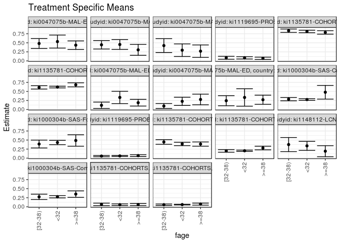

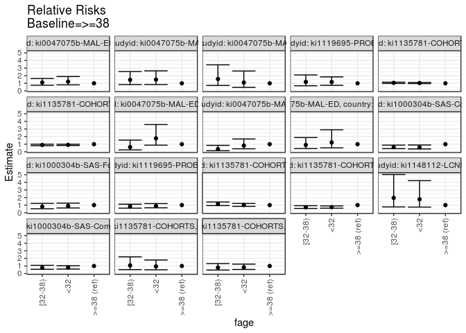

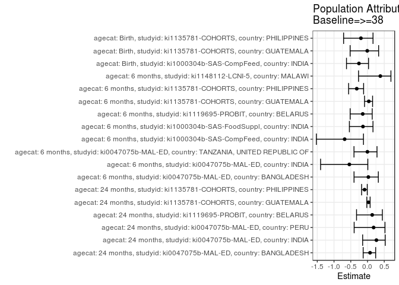

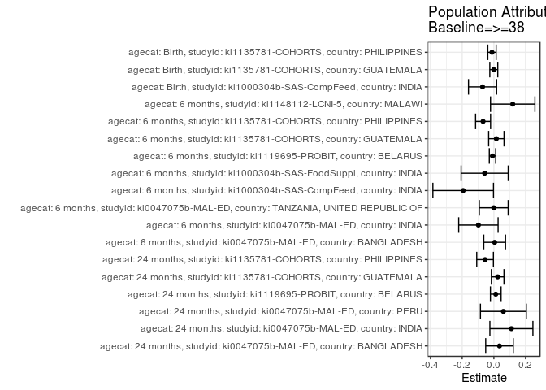

## Results Table

### Parameter: TSM

| agecat | studyid | country | intervention_level | baseline_level | estimate | ci_lower | ci_upper |
| --- | --- | --- | --- | --- | --- | --- | --- |
| Birth | ki1000304b-SAS-CompFeed | INDIA | >=38 | NA | 0.3500000 | 0.2617803 | 0.4382197 |
| Birth | ki1000304b-SAS-CompFeed | INDIA | <32 | NA | 0.2765550 | 0.2455552 | 0.3075548 |
| Birth | ki1000304b-SAS-CompFeed | INDIA | [32-38) | NA | 0.2743902 | 0.2008031 | 0.3479774 |
| Birth | ki1135781-COHORTS | GUATEMALA | >=38 | NA | 0.0612245 | 0.0311864 | 0.0912626 |
| Birth | ki1135781-COHORTS | GUATEMALA | <32 | NA | 0.0578947 | 0.0343990 | 0.0813905 |
| Birth | ki1135781-COHORTS | GUATEMALA | [32-38) | NA | 0.0656566 | 0.0311365 | 0.1001767 |
| Birth | ki1135781-COHORTS | PHILIPPINES | >=38 | NA | 0.0731707 | 0.0449834 | 0.1013580 |
| Birth | ki1135781-COHORTS | PHILIPPINES | <32 | NA | 0.0601251 | 0.0499049 | 0.0703452 |
| Birth | ki1135781-COHORTS | PHILIPPINES | [32-38) | NA | 0.0577281 | 0.0379986 | 0.0774576 |
| 6 months | ki0047075b-MAL-ED | BANGLADESH | >=38 | NA | 0.1884058 | 0.0958310 | 0.2809806 |
| 6 months | ki0047075b-MAL-ED | BANGLADESH | <32 | NA | 0.3333333 | 0.1640814 | 0.5025853 |
| 6 months | ki0047075b-MAL-ED | BANGLADESH | [32-38) | NA | 0.1176471 | 0.0289259 | 0.2063682 |
| 6 months | ki0047075b-MAL-ED | INDIA | >=38 | NA | 0.2777778 | 0.1310089 | 0.4245467 |
| 6 months | ki0047075b-MAL-ED | INDIA | <32 | NA | 0.2264151 | 0.1133913 | 0.3394389 |
| 6 months | ki0047075b-MAL-ED | INDIA | [32-38) | NA | 0.0972222 | 0.0285774 | 0.1658671 |
| 6 months | ki0047075b-MAL-ED | TANZANIA, UNITED REPUBLIC OF | >=38 | NA | 0.2708333 | 0.1444836 | 0.3971831 |
| 6 months | ki0047075b-MAL-ED | TANZANIA, UNITED REPUBLIC OF | <32 | NA | 0.3333333 | 0.0935723 | 0.5730944 |
| 6 months | ki0047075b-MAL-ED | TANZANIA, UNITED REPUBLIC OF | [32-38) | NA | 0.2432432 | 0.1043030 | 0.3821835 |
| 6 months | ki1000304b-SAS-CompFeed | INDIA | >=38 | NA | 0.4772727 | 0.2887378 | 0.6658077 |
| 6 months | ki1000304b-SAS-CompFeed | INDIA | <32 | NA | 0.2755556 | 0.2521947 | 0.2989164 |
| 6 months | ki1000304b-SAS-CompFeed | INDIA | [32-38) | NA | 0.2865854 | 0.2408141 | 0.3323566 |
| 6 months | ki1000304b-SAS-FoodSuppl | INDIA | >=38 | NA | 0.4871795 | 0.3301016 | 0.6442574 |
| 6 months | ki1000304b-SAS-FoodSuppl | INDIA | <32 | NA | 0.4318182 | 0.3719891 | 0.4916473 |
| 6 months | ki1000304b-SAS-FoodSuppl | INDIA | [32-38) | NA | 0.3896104 | 0.2805433 | 0.4986775 |
| 6 months | ki1119695-PROBIT | BELARUS | >=38 | NA | 0.0699001 | 0.0439397 | 0.0958606 |
| 6 months | ki1119695-PROBIT | BELARUS | <32 | NA | 0.0614323 | 0.0478814 | 0.0749832 |
| 6 months | ki1119695-PROBIT | BELARUS | [32-38) | NA | 0.0572420 | 0.0401314 | 0.0743525 |
| 6 months | ki1135781-COHORTS | GUATEMALA | >=38 | NA | 0.3890909 | 0.3314369 | 0.4467449 |
| 6 months | ki1135781-COHORTS | GUATEMALA | <32 | NA | 0.3919240 | 0.3452666 | 0.4385814 |
| 6 months | ki1135781-COHORTS | GUATEMALA | [32-38) | NA | 0.4463519 | 0.3824874 | 0.5102164 |
| 6 months | ki1135781-COHORTS | PHILIPPINES | >=38 | NA | 0.2800000 | 0.2291822 | 0.3308178 |
| 6 months | ki1135781-COHORTS | PHILIPPINES | <32 | NA | 0.2039366 | 0.1854675 | 0.2224057 |
| 6 months | ki1135781-COHORTS | PHILIPPINES | [32-38) | NA | 0.2000000 | 0.1647558 | 0.2352442 |
| 6 months | ki1148112-LCNI-5 | MALAWI | >=38 | NA | 0.1923077 | 0.0400985 | 0.3445169 |
| 6 months | ki1148112-LCNI-5 | MALAWI | <32 | NA | 0.3392857 | 0.2146903 | 0.4638811 |
| 6 months | ki1148112-LCNI-5 | MALAWI | [32-38) | NA | 0.3750000 | 0.1803939 | 0.5696061 |
| 24 months | ki0047075b-MAL-ED | BANGLADESH | >=38 | NA | 0.4347826 | 0.3174253 | 0.5521399 |
| 24 months | ki0047075b-MAL-ED | BANGLADESH | <32 | NA | 0.5333333 | 0.3542179 | 0.7124488 |
| 24 months | ki0047075b-MAL-ED | BANGLADESH | [32-38) | NA | 0.4807692 | 0.3445188 | 0.6170196 |
| 24 months | ki0047075b-MAL-ED | INDIA | >=38 | NA | 0.3055556 | 0.1546123 | 0.4564988 |
| 24 months | ki0047075b-MAL-ED | INDIA | <32 | NA | 0.4528302 | 0.3184015 | 0.5872588 |
| 24 months | ki0047075b-MAL-ED | INDIA | [32-38) | NA | 0.4444444 | 0.3293095 | 0.5595794 |
| 24 months | ki0047075b-MAL-ED | PERU | >=38 | NA | 0.2692308 | 0.0976454 | 0.4408161 |
| 24 months | ki0047075b-MAL-ED | PERU | <32 | NA | 0.2962963 | 0.1229596 | 0.4696330 |
| 24 months | ki0047075b-MAL-ED | PERU | [32-38) | NA | 0.4230769 | 0.2319613 | 0.6141926 |
| 24 months | ki1119695-PROBIT | BELARUS | >=38 | NA | 0.0730337 | 0.0412745 | 0.1047929 |
| 24 months | ki1119695-PROBIT | BELARUS | <32 | NA | 0.0852689 | 0.0533618 | 0.1171759 |
| 24 months | ki1119695-PROBIT | BELARUS | [32-38) | NA | 0.0867347 | 0.0460721 | 0.1273972 |
| 24 months | ki1135781-COHORTS | GUATEMALA | >=38 | NA | 0.7859649 | 0.7383237 | 0.8336061 |
| 24 months | ki1135781-COHORTS | GUATEMALA | <32 | NA | 0.8126273 | 0.7780955 | 0.8471591 |
| 24 months | ki1135781-COHORTS | GUATEMALA | [32-38) | NA | 0.8326531 | 0.7858883 | 0.8794178 |
| 24 months | ki1135781-COHORTS | PHILIPPINES | >=38 | NA | 0.6814815 | 0.6258972 | 0.7370658 |
| 24 months | ki1135781-COHORTS | PHILIPPINES | <32 | NA | 0.6206483 | 0.5973434 | 0.6439531 |
| 24 months | ki1135781-COHORTS | PHILIPPINES | [32-38) | NA | 0.6114943 | 0.5656811 | 0.6573074 |

### Parameter: E(Y)

| agecat | studyid | country | intervention_level | baseline_level | estimate | ci_lower | ci_upper |
| --- | --- | --- | --- | --- | --- | --- | --- |
| Birth | ki1000304b-SAS-CompFeed | INDIA | NA | NA | 0.2786229 | 0.2475201 | 0.3097257 |
| Birth | ki1135781-COHORTS | GUATEMALA | NA | NA | 0.0607533 | 0.0444233 | 0.0770834 |
| Birth | ki1135781-COHORTS | PHILIPPINES | NA | NA | 0.0611413 | 0.0524852 | 0.0697974 |
| 6 months | ki0047075b-MAL-ED | BANGLADESH | NA | NA | 0.1933333 | 0.1299237 | 0.2567430 |
| 6 months | ki0047075b-MAL-ED | INDIA | NA | NA | 0.1801242 | 0.1205788 | 0.2396696 |
| 6 months | ki0047075b-MAL-ED | TANZANIA, UNITED REPUBLIC OF | NA | NA | 0.2700000 | 0.1825472 | 0.3574528 |
| 6 months | ki1000304b-SAS-CompFeed | INDIA | NA | NA | 0.2835709 | 0.2656121 | 0.3015297 |
| 6 months | ki1000304b-SAS-FoodSuppl | INDIA | NA | NA | 0.4289474 | 0.3791199 | 0.4787748 |
| 6 months | ki1119695-PROBIT | BELARUS | NA | NA | 0.0611869 | 0.0477477 | 0.0746260 |
| 6 months | ki1135781-COHORTS | GUATEMALA | NA | NA | 0.4047363 | 0.3731561 | 0.4363165 |
| 6 months | ki1135781-COHORTS | PHILIPPINES | NA | NA | 0.2118902 | 0.1962516 | 0.2275288 |
| 6 months | ki1148112-LCNI-5 | MALAWI | NA | NA | 0.3113208 | 0.2227550 | 0.3998865 |
| 24 months | ki0047075b-MAL-ED | BANGLADESH | NA | NA | 0.4701987 | 0.3903257 | 0.5500716 |
| 24 months | ki0047075b-MAL-ED | INDIA | NA | NA | 0.4161491 | 0.3397719 | 0.4925262 |
| 24 months | ki0047075b-MAL-ED | PERU | NA | NA | 0.3291139 | 0.2248346 | 0.4333933 |
| 24 months | ki1119695-PROBIT | BELARUS | NA | NA | 0.0849322 | 0.0549995 | 0.1148649 |
| 24 months | ki1135781-COHORTS | GUATEMALA | NA | NA | 0.8099902 | 0.7859147 | 0.8340657 |
| 24 months | ki1135781-COHORTS | PHILIPPINES | NA | NA | 0.6258962 | 0.6064148 | 0.6453777 |

### Parameter: RR

| agecat | studyid | country | intervention_level | baseline_level | estimate | ci_lower | ci_upper |
| --- | --- | --- | --- | --- | --- | --- | --- |
| Birth | ki1000304b-SAS-CompFeed | INDIA | >=38 | >=38 | 1.0000000 | 1.0000000 | 1.0000000 |
| Birth | ki1000304b-SAS-CompFeed | INDIA | <32 | >=38 | 0.7901572 | 0.6005631 | 1.0396050 |
| Birth | ki1000304b-SAS-CompFeed | INDIA | [32-38) | >=38 | 0.7839721 | 0.5641978 | 1.0893560 |
| Birth | ki1135781-COHORTS | GUATEMALA | >=38 | >=38 | 1.0000000 | 1.0000000 | 1.0000000 |
| Birth | ki1135781-COHORTS | GUATEMALA | <32 | >=38 | 0.9456140 | 0.5002530 | 1.7874675 |
| Birth | ki1135781-COHORTS | GUATEMALA | [32-38) | >=38 | 1.0723906 | 0.5224451 | 2.2012293 |
| Birth | ki1135781-COHORTS | PHILIPPINES | >=38 | >=38 | 1.0000000 | 1.0000000 | 1.0000000 |
| Birth | ki1135781-COHORTS | PHILIPPINES | <32 | >=38 | 0.8217092 | 0.5393283 | 1.2519385 |
| Birth | ki1135781-COHORTS | PHILIPPINES | [32-38) | >=38 | 0.7889510 | 0.4714085 | 1.3203912 |
| 6 months | ki0047075b-MAL-ED | BANGLADESH | >=38 | >=38 | 1.0000000 | 1.0000000 | 1.0000000 |
| 6 months | ki0047075b-MAL-ED | BANGLADESH | <32 | >=38 | 1.7692308 | 0.8728158 | 3.5862980 |
| 6 months | ki0047075b-MAL-ED | BANGLADESH | [32-38) | >=38 | 0.6244344 | 0.2538556 | 1.5359844 |
| 6 months | ki0047075b-MAL-ED | INDIA | >=38 | >=38 | 1.0000000 | 1.0000000 | 1.0000000 |
| 6 months | ki0047075b-MAL-ED | INDIA | <32 | >=38 | 0.8150943 | 0.3940268 | 1.6861258 |
| 6 months | ki0047075b-MAL-ED | INDIA | [32-38) | >=38 | 0.3500000 | 0.1449028 | 0.8453946 |
| 6 months | ki0047075b-MAL-ED | TANZANIA, UNITED REPUBLIC OF | >=38 | >=38 | 1.0000000 | 1.0000000 | 1.0000000 |
| 6 months | ki0047075b-MAL-ED | TANZANIA, UNITED REPUBLIC OF | <32 | >=38 | 1.2307692 | 0.5222084 | 2.9007439 |
| 6 months | ki0047075b-MAL-ED | TANZANIA, UNITED REPUBLIC OF | [32-38) | >=38 | 0.8981289 | 0.4295810 | 1.8777263 |
| 6 months | ki1000304b-SAS-CompFeed | INDIA | >=38 | >=38 | 1.0000000 | 1.0000000 | 1.0000000 |
| 6 months | ki1000304b-SAS-CompFeed | INDIA | <32 | >=38 | 0.5773545 | 0.3723486 | 0.8952315 |
| 6 months | ki1000304b-SAS-CompFeed | INDIA | [32-38) | >=38 | 0.6004646 | 0.4096962 | 0.8800612 |
| 6 months | ki1000304b-SAS-FoodSuppl | INDIA | >=38 | >=38 | 1.0000000 | 1.0000000 | 1.0000000 |
| 6 months | ki1000304b-SAS-FoodSuppl | INDIA | <32 | >=38 | 0.8863636 | 0.6240281 | 1.2589826 |
| 6 months | ki1000304b-SAS-FoodSuppl | INDIA | [32-38) | >=38 | 0.7997266 | 0.5217965 | 1.2256937 |
| 6 months | ki1119695-PROBIT | BELARUS | >=38 | >=38 | 1.0000000 | 1.0000000 | 1.0000000 |
| 6 months | ki1119695-PROBIT | BELARUS | <32 | >=38 | 0.8788584 | 0.6436826 | 1.1999579 |
| 6 months | ki1119695-PROBIT | BELARUS | [32-38) | >=38 | 0.8189107 | 0.5991811 | 1.1192190 |
| 6 months | ki1135781-COHORTS | GUATEMALA | >=38 | >=38 | 1.0000000 | 1.0000000 | 1.0000000 |
| 6 months | ki1135781-COHORTS | GUATEMALA | <32 | >=38 | 1.0072813 | 0.8329182 | 1.2181455 |
| 6 months | ki1135781-COHORTS | GUATEMALA | [32-38) | >=38 | 1.1471662 | 0.9336191 | 1.4095580 |
| 6 months | ki1135781-COHORTS | PHILIPPINES | >=38 | >=38 | 1.0000000 | 1.0000000 | 1.0000000 |
| 6 months | ki1135781-COHORTS | PHILIPPINES | <32 | >=38 | 0.7283449 | 0.5946318 | 0.8921258 |
| 6 months | ki1135781-COHORTS | PHILIPPINES | [32-38) | >=38 | 0.7142857 | 0.5546372 | 0.9198880 |
| 6 months | ki1148112-LCNI-5 | MALAWI | >=38 | >=38 | 1.0000000 | 1.0000000 | 1.0000000 |
| 6 months | ki1148112-LCNI-5 | MALAWI | <32 | >=38 | 1.7642857 | 0.7372819 | 4.2218641 |
| 6 months | ki1148112-LCNI-5 | MALAWI | [32-38) | >=38 | 1.9500000 | 0.7568292 | 5.0242509 |
| 24 months | ki0047075b-MAL-ED | BANGLADESH | >=38 | >=38 | 1.0000000 | 1.0000000 | 1.0000000 |
| 24 months | ki0047075b-MAL-ED | BANGLADESH | <32 | >=38 | 1.2266667 | 0.7972654 | 1.8873402 |
| 24 months | ki0047075b-MAL-ED | BANGLADESH | [32-38) | >=38 | 1.1057692 | 0.7476405 | 1.6354460 |
| 24 months | ki0047075b-MAL-ED | INDIA | >=38 | >=38 | 1.0000000 | 1.0000000 | 1.0000000 |
| 24 months | ki0047075b-MAL-ED | INDIA | <32 | >=38 | 1.4819897 | 0.8328118 | 2.6372025 |
| 24 months | ki0047075b-MAL-ED | INDIA | [32-38) | >=38 | 1.4545455 | 0.8326794 | 2.5408368 |
| 24 months | ki0047075b-MAL-ED | PERU | >=38 | >=38 | 1.0000000 | 1.0000000 | 1.0000000 |
| 24 months | ki0047075b-MAL-ED | PERU | <32 | >=38 | 1.1005291 | 0.4633297 | 2.6140444 |
| 24 months | ki0047075b-MAL-ED | PERU | [32-38) | >=38 | 1.5714286 | 0.7195080 | 3.4320507 |
| 24 months | ki1119695-PROBIT | BELARUS | >=38 | >=38 | 1.0000000 | 1.0000000 | 1.0000000 |
| 24 months | ki1119695-PROBIT | BELARUS | <32 | >=38 | 1.1675274 | 0.7382154 | 1.8465073 |
| 24 months | ki1119695-PROBIT | BELARUS | [32-38) | >=38 | 1.1875981 | 0.6725161 | 2.0971831 |
| 24 months | ki1135781-COHORTS | GUATEMALA | >=38 | >=38 | 1.0000000 | 1.0000000 | 1.0000000 |
| 24 months | ki1135781-COHORTS | GUATEMALA | <32 | >=38 | 1.0339231 | 0.9601498 | 1.1133648 |
| 24 months | ki1135781-COHORTS | GUATEMALA | [32-38) | >=38 | 1.0594023 | 0.9753783 | 1.1506646 |
| 24 months | ki1135781-COHORTS | PHILIPPINES | >=38 | >=38 | 1.0000000 | 1.0000000 | 1.0000000 |
| 24 months | ki1135781-COHORTS | PHILIPPINES | <32 | >=38 | 0.9107339 | 0.8325212 | 0.9962944 |
| 24 months | ki1135781-COHORTS | PHILIPPINES | [32-38) | >=38 | 0.8973013 | 0.8032301 | 1.0023898 |

### Parameter: PAR

| agecat | studyid | country | intervention_level | baseline_level | estimate | ci_lower | ci_upper |
| --- | --- | --- | --- | --- | --- | --- | --- |
| Birth | ki1000304b-SAS-CompFeed | INDIA | >=38 | NA | -0.0713771 | -0.1601573 | 0.0174030 |
| Birth | ki1135781-COHORTS | GUATEMALA | >=38 | NA | -0.0004711 | -0.0256058 | 0.0246635 |
| Birth | ki1135781-COHORTS | PHILIPPINES | >=38 | NA | -0.0120294 | -0.0383431 | 0.0142843 |
| 6 months | ki0047075b-MAL-ED | BANGLADESH | >=38 | NA | 0.0049275 | -0.0636756 | 0.0735307 |
| 6 months | ki0047075b-MAL-ED | INDIA | >=38 | NA | -0.0976536 | -0.2219655 | 0.0266584 |
| 6 months | ki0047075b-MAL-ED | TANZANIA, UNITED REPUBLIC OF | >=38 | NA | -0.0008333 | -0.0918639 | 0.0901972 |
| 6 months | ki1000304b-SAS-CompFeed | INDIA | >=38 | NA | -0.1937018 | -0.3849385 | -0.0024652 |
| 6 months | ki1000304b-SAS-FoodSuppl | INDIA | >=38 | NA | -0.0582321 | -0.2068649 | 0.0904006 |
| 6 months | ki1119695-PROBIT | BELARUS | >=38 | NA | -0.0087133 | -0.0288182 | 0.0113916 |
| 6 months | ki1135781-COHORTS | GUATEMALA | >=38 | NA | 0.0156454 | -0.0328663 | 0.0641570 |
| 6 months | ki1135781-COHORTS | PHILIPPINES | >=38 | NA | -0.0681098 | -0.1154015 | -0.0208180 |
| 6 months | ki1148112-LCNI-5 | MALAWI | >=38 | NA | 0.1190131 | -0.0211521 | 0.2591783 |
| 24 months | ki0047075b-MAL-ED | BANGLADESH | >=38 | NA | 0.0354161 | -0.0515634 | 0.1223955 |
| 24 months | ki0047075b-MAL-ED | INDIA | >=38 | NA | 0.1105935 | -0.0251573 | 0.2463443 |
| 24 months | ki0047075b-MAL-ED | PERU | >=38 | NA | 0.0598832 | -0.0848113 | 0.2045776 |
| 24 months | ki1119695-PROBIT | BELARUS | >=38 | NA | 0.0118985 | -0.0217390 | 0.0455360 |
| 24 months | ki1135781-COHORTS | GUATEMALA | >=38 | NA | 0.0240253 | -0.0157516 | 0.0638022 |
| 24 months | ki1135781-COHORTS | PHILIPPINES | >=38 | NA | -0.0555852 | -0.1081730 | -0.0029974 |

### Parameter: PAF

| agecat | studyid | country | intervention_level | baseline_level | estimate | ci_lower | ci_upper |
| --- | --- | --- | --- | --- | --- | --- | --- |
| Birth | ki1000304b-SAS-CompFeed | INDIA | >=38 | NA | -0.2561782 | -0.6275781 | 0.0304714 |
| Birth | ki1135781-COHORTS | GUATEMALA | >=38 | NA | -0.0077551 | -0.5193057 | 0.3315563 |
| Birth | ki1135781-COHORTS | PHILIPPINES | >=38 | NA | -0.1967480 | -0.7135925 | 0.1642087 |
| 6 months | ki0047075b-MAL-ED | BANGLADESH | >=38 | NA | 0.0254873 | -0.4024951 | 0.3228674 |
| 6 months | ki0047075b-MAL-ED | INDIA | >=38 | NA | -0.5421456 | -1.4008101 | 0.0094123 |
| 6 months | ki0047075b-MAL-ED | TANZANIA, UNITED REPUBLIC OF | >=38 | NA | -0.0030864 | -0.4038159 | 0.2832519 |
| 6 months | ki1000304b-SAS-CompFeed | INDIA | >=38 | NA | -0.6830808 | -1.5272725 | -0.1208767 |
| 6 months | ki1000304b-SAS-FoodSuppl | INDIA | >=38 | NA | -0.1357559 | -0.5412746 | 0.1630684 |
| 6 months | ki1119695-PROBIT | BELARUS | >=38 | NA | -0.1424046 | -0.5182035 | 0.1403733 |
| 6 months | ki1135781-COHORTS | GUATEMALA | >=38 | NA | 0.0386557 | -0.0890099 | 0.1513550 |
| 6 months | ki1135781-COHORTS | PHILIPPINES | >=38 | NA | -0.3214388 | -0.5641523 | -0.1163879 |
| 6 months | ki1148112-LCNI-5 | MALAWI | >=38 | NA | 0.3822844 | -0.2683064 | 0.6991479 |
| 24 months | ki0047075b-MAL-ED | BANGLADESH | >=38 | NA | 0.0753215 | -0.1298108 | 0.2432093 |
| 24 months | ki0047075b-MAL-ED | INDIA | >=38 | NA | 0.2657546 | -0.1452182 | 0.5292457 |
| 24 months | ki0047075b-MAL-ED | PERU | >=38 | NA | 0.1819527 | -0.3989032 | 0.5216242 |
| 24 months | ki1119695-PROBIT | BELARUS | >=38 | NA | 0.1400941 | -0.3276707 | 0.4430560 |
| 24 months | ki1135781-COHORTS | GUATEMALA | >=38 | NA | 0.0296612 | -0.0207711 | 0.0776019 |
| 24 months | ki1135781-COHORTS | PHILIPPINES | >=38 | NA | -0.0888090 | -0.1762856 | -0.0078378 |